# 31010 - Assignment 3

Melanie Tran

2/8/2021

Derive the analytical version of the Newton-Raphson algorithm (including $f(x)$ and $f′(x))$ for each expression below (separately). For each expression below, implement the Newton-Raphson algorithm, and find at least one root for each non-linear function below. Also plot $f(x)$ around the solution(s). Prepare a data table with values for $x$, $f(x)$, $f′(x)$, and err for each iteration.

– Q1 PART 1: **$3x^2−2x−4 = 0$**

*Apply Newton-Raphson method to find first root.*

```r
tol <- 10^(-5)
err <- 10^5
x0 <- 0.3
```

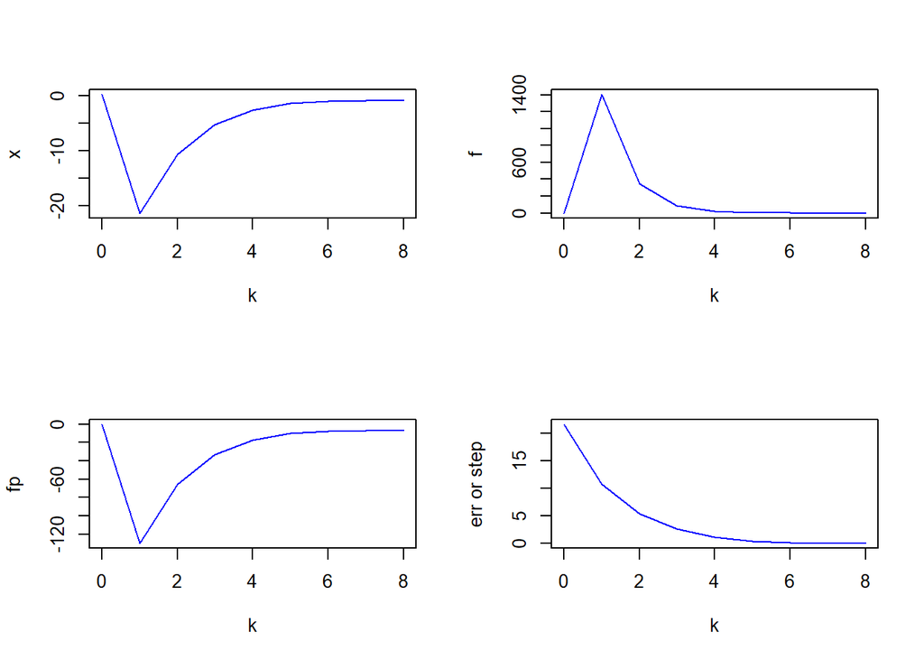

```r
x <- NULL
f <- function(x){
  (3*(x**2))- (2*x)- 4
}

fp <- function(x){
  (6*x - 2)
}

k <- 0
dta <- NULL

while (err>tol){
    x <- x0 - f(x0)/fp(x0)
    err <- abs(x-x0)
    dta <- rbind(dta,data.frame(k=k,x=x0,f=f(x0),fp=fp(x0),err=err))
    x0 <- x
    k <- k + 1
}

par(mfrow=c(2,2))
plot(dta$k,dta$x,type="l",col="blue",xlab="k",ylab="x")
plot(dta$k,dta$f,type="l",col="blue",xlab="k",ylab="f")
plot(dta$k,dta$fp,type="l",col="blue",xlab="k",ylab="fp")
plot(dta$k,dta$err,type="l",col="blue",xlab="k",ylab="err or step")
```

*Data for first root.*

```r
dta
```

```
##   k           x             f          fp          err
## 1 0   0.3000000 -4.330000e+00   -0.200000 2.165000e+01
## 2 1 -21.3500000  1.406167e+03 -130.100000 1.080836e+01
## 3 2 -10.5416410  3.504619e+02  -65.249846 5.371076e+00
## 4 3  -5.1705653  8.654537e+01  -33.023392 2.620729e+00
## 5 4  -2.5498361  2.060466e+01  -17.299016 1.191089e+00
## 6 5  -1.3587473  4.256077e+00  -10.152484 4.192154e-01
## 7 6  -0.9395319  5.272246e-01   -7.637192 6.903383e-02
## 8 7  -0.8704981  1.429701e-02   -7.222989 1.979376e-03
## 9 8  -0.8685187  1.175379e-05   -7.211112 1.629955e-06
```

*Identify first root.*

```r
q1_root1 <- x0
```

*Apply Newton-Raphson method to find second root.*

```r
tol <- 10^(-5)
err <- 10^5
x0 <- 1
```

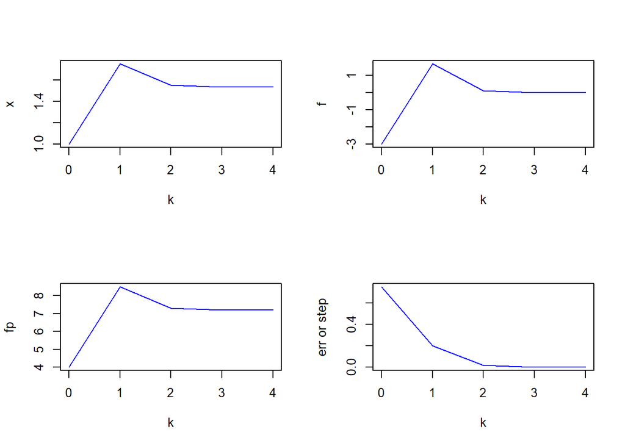

```r
x <- NULL
f <- function(x){
  (3*x**2)- (2*x)- 4
}

fp <- function(x){
  (6*x - 2)
}

k <- 0
dta <- NULL

while (err>tol){
    x <- x0 - f(x0)/fp(x0)
    err <- abs(x-x0)
    dta <- rbind(dta,data.frame(k=k,x=x0,f=f(x0),fp=fp(x0),err=err))
    x0 <- x
    k <- k + 1
}

par(mfrow=c(2,2))
plot(dta$k,dta$x,type="l",col="blue",xlab="k",ylab="x")
plot(dta$k,dta$f,type="l",col="blue",xlab="k",ylab="f")
plot(dta$k,dta$fp,type="l",col="blue",xlab="k",ylab="fp")
plot(dta$k,dta$err,type="l",col="blue",xlab="k",ylab="err or step")
```

*Data for second root.*

```r
dta
```

```
##   k        x             f       fp          err
## 1 0 1.000000 -3.000000e+00 4.000000 7.500000e-01
## 2 1 1.750000  1.687500e+00 8.500000 1.985294e-01
## 3 2 1.551471  1.182418e-01 7.308824 1.617795e-02
## 4 3 1.535293  7.851782e-04 7.211756 1.088748e-04
## 5 4 1.535184  3.556114e-08 7.211103 4.931443e-09
```

Identify second root.

```r
q1_root2 <- x0
```

*Identify roots for $3x^2−2x−4 = 0$.*

```r
q1_root1
```

```
## [1] -0.8685171
```

```r
q1_root2
```

```
## [1] 1.535184
```

– Q1 PART 2: **$e^x−x^4 = 0$**

*Apply Newton-Raphson method to find first root.*

```r
tol <- 10^(-5)
err <- 10^5
x0 <- 0.9
```

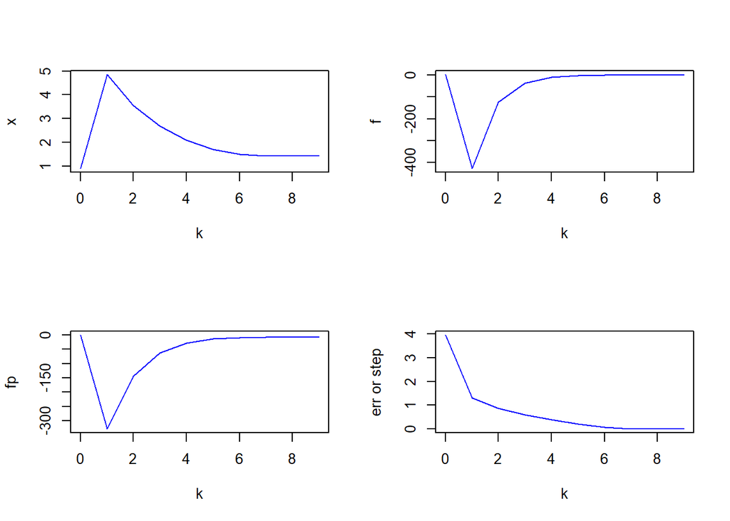

```r
x <- NULL
f <- function(x){
  (exp(1)**x) - (x**4)
}

fp <- function(x){
  (exp(1)**x) - (4*x**3)
}

k <- 0
dta <- NULL

while (err>tol){
    x <- x0 - f(x0)/fp(x0)
    err <- abs(x-x0)
    dta <- rbind(dta,data.frame(k=k,x=x0,f=f(x0),fp=fp(x0),err=err))
    x0 <- x
    k <- k + 1
}

par(mfrow=c(2,2))
plot(dta$k,dta$x,type="l",col="blue",xlab="k",ylab="x")
plot(dta$k,dta$f,type="l",col="blue",xlab="k",ylab="f")
plot(dta$k,dta$fp,type="l",col="blue",xlab="k",ylab="fp")
plot(dta$k,dta$err,type="l",col="blue",xlab="k",ylab="err or step")
```

*Data for first root.*

```r
dta
```

```
##    k        x             f           fp          err
## 1  0 0.900000  1.803503e+00   -0.4563969 3.951611e+00
## 2  1 4.851611 -4.260973e+02 -328.8450916 1.295739e+00
## 3  2 3.555873 -1.248582e+02 -144.8267294 8.621212e-01
## 4  3 2.693751 -3.786680e+01  -63.3995957 5.972719e-01
## 5  4 2.096480 -1.118054e+01  -28.7205363 3.892874e-01
## 6  5 1.707192 -2.980880e+00  -14.3890204 2.071635e-01
## 7  6 1.500029 -5.810687e-01   -9.0189545 6.442750e-02
## 8  7 1.435601 -4.534672e-02   -7.6326408 5.941157e-03
## 9  8 1.429660 -3.612575e-04   -7.5112066 4.809580e-05
## 10 9 1.429612 -2.353614e-08   -7.5102279 3.133878e-09
```

*Identify first root for for $e^x−x^4 = 0$.*

```r
(q2_root1 <- x0)
```

```
## [1] 1.429612
```

*Apply Newton-Raphson method to find second root.*

```r
tol <- 10^(-5)
err <- 10^5
x0 <- 0.1
```

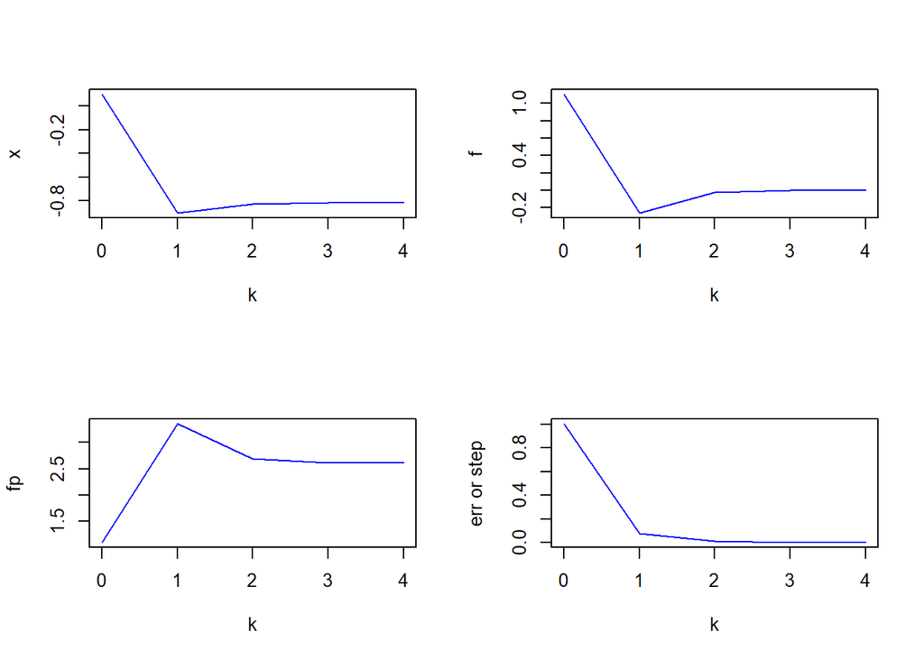

```r
x <- NULL
f <- function(x){
  (exp(1)**x) - (x**4)
}

fp <- function(x){
  (exp(1)**x) - (4*x**3)
}

k <- 0
dta <- NULL

while (err>tol){
    x <- x0 - f(x0)/fp(x0)
    err <- abs(x-x0)
    dta <- rbind(dta,data.frame(k=k,x=x0,f=f(x0),fp=fp(x0),err=err))
    x0 <- x
    k <- k + 1
}

par(mfrow=c(2,2))
plot(dta$k,dta$x,type="l",col="blue",xlab="k",ylab="x")
plot(dta$k,dta$f,type="l",col="blue",xlab="k",ylab="f")
plot(dta$k,dta$fp,type="l",col="blue",xlab="k",ylab="fp")
plot(dta$k,dta$err,type="l",col="blue",xlab="k",ylab="err or step")
```

*Data for second root.*

```r
dta
```

```
##   k          x             f       fp          err
## 1 0  0.1000000  1.105071e+00 1.101171 1.003542e+00
## 2 1 -0.9035417 -2.613564e-01 3.355693 7.788448e-02
## 3 2 -0.8256572 -2.678120e-02 2.689382 9.958127e-03
## 4 3 -0.8156991 -3.805695e-04 2.613280 1.456290e-04
## 5 4 -0.8155534 -7.996491e-08 2.612182 3.061230e-08
```

*Identify second root for $e^x−x^4 = 0$.*

```r
(q2_root2 <- x0)
```

```
## [1] -0.8155534
```

*Identify roots for $e^x−x^4 = 0$.*

```r
q2_root1
```

```
## [1] 1.429612
```

```r
q2_root2
```

```
## [1] -0.8155534
```

– Q1 PART 3: **$x^3+4x^2−10=0$**

*Apply Newton-Raphson method.*

```r
tol <- 10^(-5)
err <- 10^5
x0 <- 1.5
```

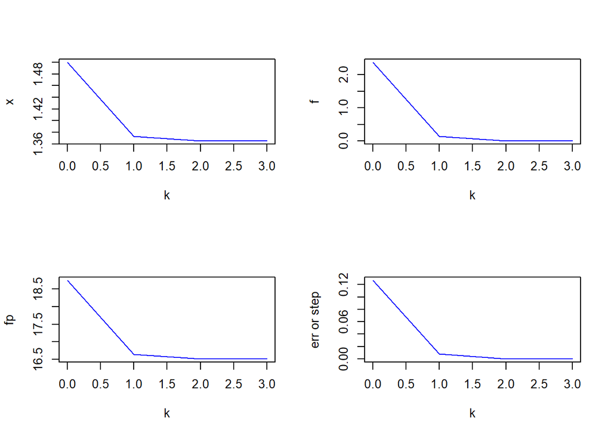

```r
x <- NULL
f <- function(x){
  (x**3) + (4*x**2)- 10
}

fp <- function(x){
  (3*x**2 + 8*x)
}

k <- 0
dta <- NULL

while (err>tol){
    x <- x0 - f(x0)/fp(x0)
    err <- abs(x-x0)
    dta <- rbind(dta,data.frame(k=k,x=x0,f=f(x0),fp=fp(x0),err=err))
    x0 <- x
    k <- k + 1
}

par(mfrow=c(2,2))
plot(dta$k,dta$x,type="l",col="blue",xlab="k",ylab="x")
plot(dta$k,dta$f,type="l",col="blue",xlab="k",ylab="f")
plot(dta$k,dta$fp,type="l",col="blue",xlab="k",ylab="fp")
plot(dta$k,dta$err,type="l",col="blue",xlab="k",ylab="err or step")
```

*Data for root.*

```r
dta
```

```
##   k        x            f       fp          err
## 1 0 1.500000 2.375000e+00 18.75000 1.266667e-01
## 2 1 1.373333 1.343455e-01 16.64480 8.071318e-03
## 3 2 1.365262 5.284612e-04 16.51392 3.200096e-05
## 4 3 1.365230 8.290549e-09 16.51340 5.020497e-10
```

```r
(q3_root <- x0)
```

```
## [1] 1.36523
```

– Q1 PART 4: **$x−e^{-x^2}=0$**

*Apply Newton-Raphson method.*

```r
tol <- 10^(-5)
err <- 10^5
x0 <- 0.1
```

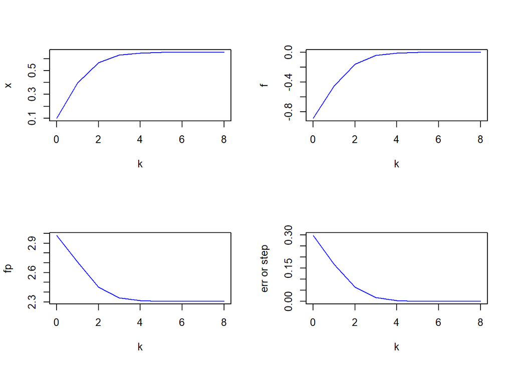

```r
x <- NULL
f <- function(x){
  x - (exp(1)**(-x**2))
}

fp <- function(x){
  (2*exp(-x^2) + 1)
}

k <- 0
dta <- NULL

while (err>tol){
    x <- x0 - f(x0)/fp(x0)
    err <- abs(x-x0)
    dta <- rbind(dta,data.frame(k=k,x=x0,f=f(x0),fp=fp(x0),err=err))
    x0 <- x
    k <- k + 1
}

par(mfrow=c(2,2))
plot(dta$k,dta$x,type="l",col="blue",xlab="k",ylab="x")
plot(dta$k,dta$f,type="l",col="blue",xlab="k",ylab="f")
plot(dta$k,dta$fp,type="l",col="blue",xlab="k",ylab="fp")
plot(dta$k,dta$err,type="l",col="blue",xlab="k",ylab="err or step")
```

*Data for root.*

```r
dta
```

```
##   k         x             f       fp          err
## 1 0 0.1000000 -8.900498e-01 2.980100 2.986645e-01
## 2 1 0.3986645 -4.543888e-01 2.706106 1.679124e-01
## 3 2 0.5665768 -1.588397e-01 2.450833 6.481048e-02
## 4 3 0.6313873 -3.983832e-02 2.342451 1.700711e-02
## 5 4 0.6483944 -8.379571e-03 2.313548 3.621957e-03
## 6 5 0.6520164 -1.671461e-03 2.307376 7.243993e-04
## 7 6 0.6527408 -3.295109e-04 2.306141 1.428842e-04
## 8 7 0.6528837 -6.480591e-05 2.305897 2.810442e-05
## 9 8 0.6529118 -1.273961e-05 2.305849 5.524910e-06
```

*Identify root for $x−e^{-x^2}=0$*

```r
(q4_root <- x0)
```

```
## [1] 0.6529173
```

2. Write a R code for $f(x)$ and $Df(x)$. Run the Newthon-Raphson method and search for the solution. Prepare a table with values for $x$, $f(x)$, $Df^{−1}(x)$, and err for each iteration. Explain what is happening during the iterations. Is the algorithm converging? Why or why not? Choose your initial values carefully.

```r
tol <- 10^(-10)
err <- 10^5
x0 <- matrix(c(1,1,1))
```

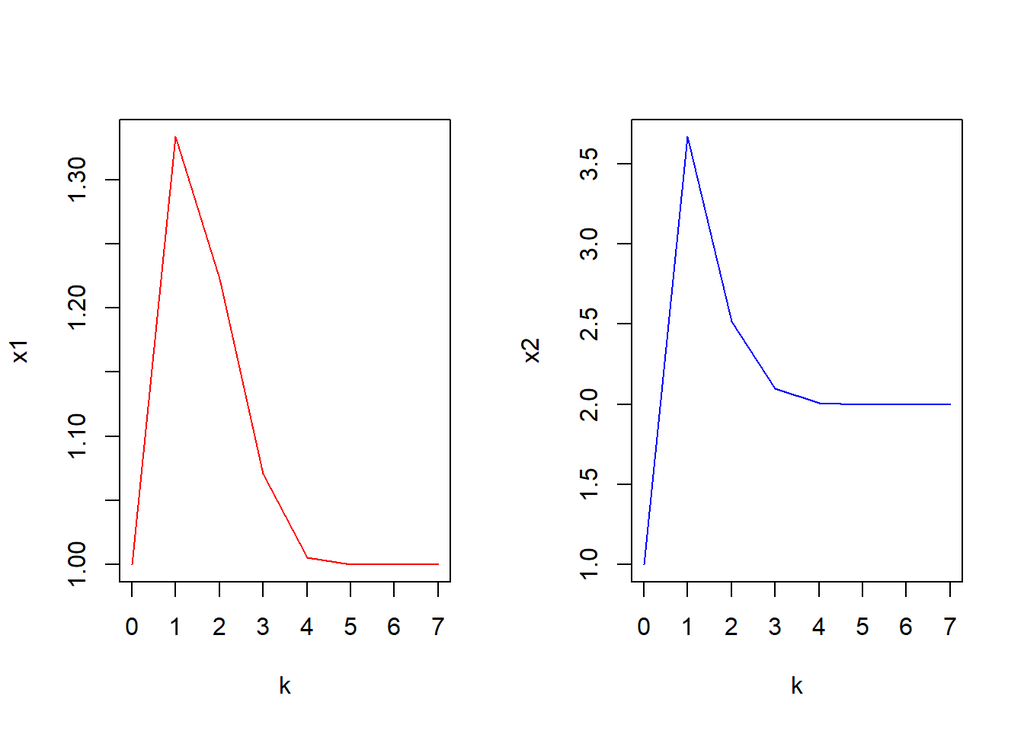

```r
x <- NULL
f <- function(x){
  matrix(c((x[1] + x[2] + x[3]**2 -12),
            (x[1]**2 -x[2] + x[3] - 2),
            (2*x[1]**2 -x[2]**2 + x[3] - 1)),byrow=TRUE,nrow=length(x))
}
Df <- function(x){
  (matrix(c(1, 1, 2*x[3],
            2*x[1],-1,1,
            4*x[1], -2*x[2],1), byrow = TRUE, nrow=length(x)))
}

k <- 0
dta <- NULL

while (err>tol){
    x <- x0 - solve(Df(x0)) %*% f(x0)
    err <- max(abs(x-x0))
    dta <- rbind(dta,data.frame(k=rep(k,length(x0)),x=x0,f=f(x0),invDf=solve(Df(x0)),err=x-x0))
    x0 <- x
    k <- k + 1
}

dta1 <- aggregate(x~k,dta,FUN=head,1)
dta2 <- aggregate(x~k,dta,FUN=tail,2)
dta3 <- aggregate(x~k,dta, FUN = tail,1)


par(mfrow=c(1,2))
plot(dta1$k,dta1$x,type="l",col="red",xlab="k",ylab="x1")
plot(dta2$k,dta2$x[,1],type="l",col="blue",xlab="k",ylab="x2")
```

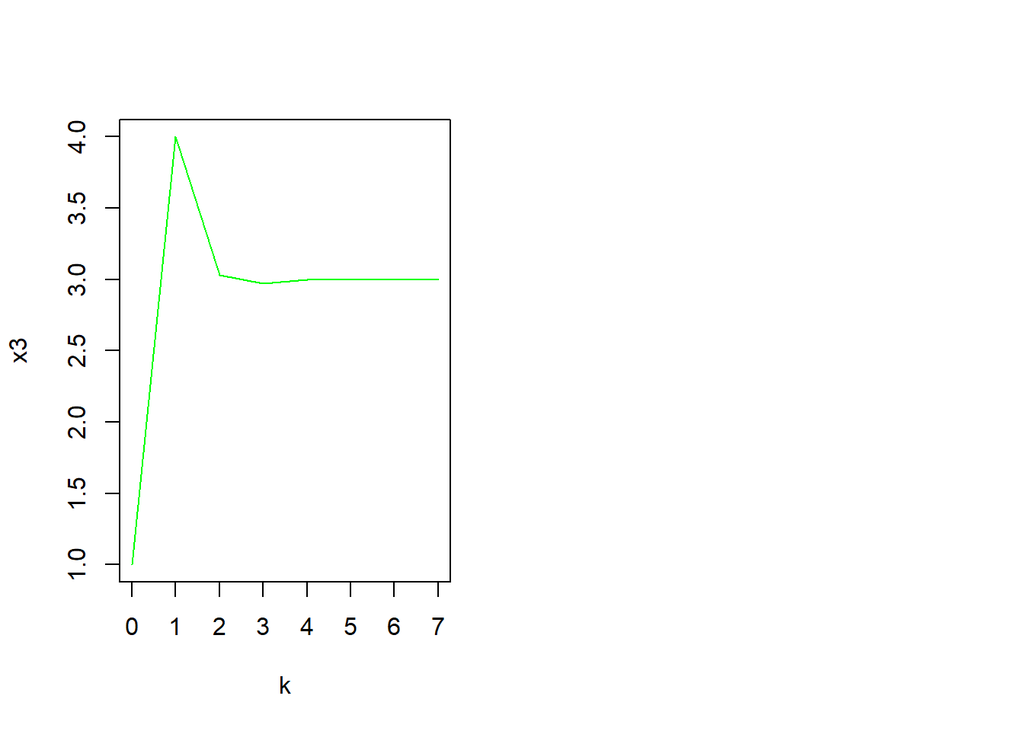

```r
plot(dta3$k,dta3$x,type="l",col="green",xlab="k",ylab="x3")
```

*Combined results of $x$, $f(x)$, $Df−1(x)$, and err for each iteration.*

```r
dta
```

```
##    k        x             f     invDf.1    invDf.2     invDf.3           err
## 1  0 1.000000 -9.000000e+00  0.33333333 -1.6666667  1.00000000  3.333333e-01
## 2  0 1.000000 -1.000000e+00  0.66666667 -2.3333333  1.00000000  2.666667e+00
## 3  0 1.000000  1.000000e+00  0.00000000  2.0000000 -1.00000000  3.000000e+00
## 4  1 1.333333  9.000000e+00 -0.06044539  0.5694592 -0.08589608 -1.109933e-01
## 5  1 3.666667  1.111111e-01 -0.02545069  0.3976670 -0.19406151 -1.151997e+00
## 6  1 4.000000 -6.888889e+00  0.13573701 -0.1208908  0.03499470 -9.671262e-01
## 7  2 1.222340  9.353331e-01 -0.10480112  0.8194737 -0.18377661 -1.514330e-01
## 8  2 2.514669  1.231951e-02 -0.06358492  0.7453707 -0.35968059 -4.181785e-01
## 9  2 3.032874 -1.302458e+00  0.19262029 -0.2579805  0.08959443 -6.029291e-02
## 10 3 1.070907  3.635235e-03 -0.14134875  1.1477936 -0.30745239 -6.547155e-02
## 11 3 2.096491  2.293194e-02 -0.09481505  1.0831131 -0.51942227 -9.150357e-02
## 12 3 2.972581 -1.290094e-01  0.20792770 -0.3752474  0.13908363  2.579238e-02
## 13 4 1.005436  6.652470e-04 -0.15663242  1.3033802 -0.36409521 -5.409900e-03
## 14 4 2.004987  4.286524e-03 -0.10464128  1.2029767 -0.57546945 -4.971799e-03
## 15 4 2.998373  2.001443e-04  0.21032633 -0.4179528  0.15667907  1.620287e-03
## 16 5 1.000026  2.625331e-06 -0.15788927  1.3157374 -0.36840379 -2.563553e-05
## 17 5 2.000016  2.926701e-05 -0.10526112  1.2105015 -0.57893615 -1.557456e-05
## 18 5 2.999994  3.381524e-05  0.21052552 -0.4210407  0.15789033  6.430806e-06
## 19 6 1.000000  4.135359e-11 -0.15789474  1.3157895 -0.36842105 -4.633104e-10
## 20 6 2.000000  6.571810e-10 -0.10526316  1.2105263 -0.57894737 -1.706688e-10
## 21 6 3.000000  1.071795e-09  0.21052632 -0.4210526  0.15789474  9.877077e-11
## 22 7 1.000000  0.000000e+00 -0.15789474  1.3157895 -0.36842105  1.110223e-16
## 23 7 2.000000 -2.220446e-16 -0.10526316  1.2105263 -0.57894737  0.000000e+00
## 24 7 3.000000 -4.440892e-16  0.21052632 -0.4210526  0.15789474  0.000000e+00
```

```r
dta1
```

```
##   k        x
## 1 0 1.000000
## 2 1 1.333333
## 3 2 1.222340
## 4 3 1.070907
## 5 4 1.005436
## 6 5 1.000026
## 7 6 1.000000
## 8 7 1.000000
```

```r
dta2
```

```
##   k      x.1      x.2
## 1 0 1.000000 1.000000
## 2 1 3.666667 4.000000
## 3 2 2.514669 3.032874
## 4 3 2.096491 2.972581
## 5 4 2.004987 2.998373
## 6 5 2.000016 2.999994
## 7 6 2.000000 3.000000
## 8 7 2.000000 3.000000
```

```r
dta3
```

```
##   k        x
## 1 0 1.000000
## 2 1 4.000000
## 3 2 3.032874
## 4 3 2.972581
## 5 4 2.998373
## 6 5 2.999994
## 7 6 3.000000
## 8 7 3.000000
```